# Analysis of World Happiness

## 4.5 Random Forest Regression for Happyniess Score Prediction

```r
library(randomForest)

x_train_rf<-select(dataset,-c("Happiness.Score"))


set.seed(1234)
regressor_rf = randomForest(x = x_train_rf,
                         y = dataset$Happiness.Score,
                         ntree = 500)
```

### 4.5.2 Predict happiness score with data_test

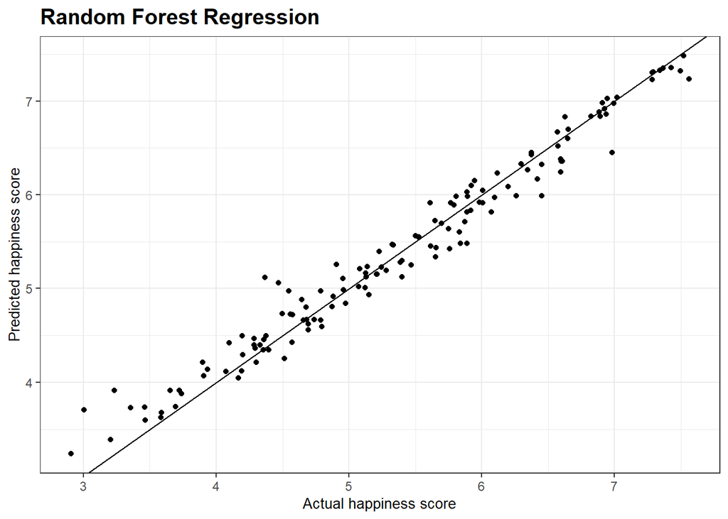

```r
# Predicting happiness score with Random Forest Regression
y_pred_rf = predict(regressor_rf, newdata = data_test)

Pred_Actual_rf <- as.data.frame(cbind(Prediction = y_pred_rf, Actual = data_test$Happiness.Score))


gg.rf <- ggplot(Pred_Actual_rf, aes(Actual, Prediction )) +
  geom_point() + theme_bw() + geom_abline() +
  labs(title = "Random Forest Regression", x = "Actual happiness score",
       y = "Predicted happiness score") +
  theme(plot.title = element_text(family = "Helvetica", face = "bold", size = (15)),
        axis.title = element_text(family = "Helvetica", size = (10)))
gg.rf
```

```r
data.frame(
  R2 = R2(y_pred_rf, data_test$Happiness.Score),
  RMSE = RMSE(y_pred_rf, data_test$Happiness.Score),
  MAE = MAE(y_pred_rf, data_test$Happiness.Score)
)
```

```
##          R2      RMSE       MAE
## 1 0.9692887 0.2104387 0.1561681
```

## 4.6 Model Evaluation

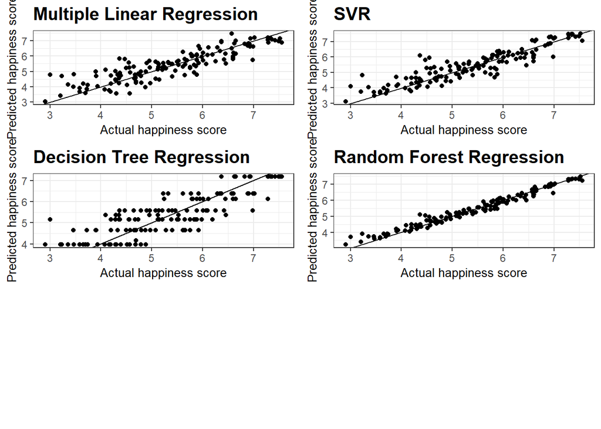

```r
ggarrange(gg.lm, gg.svr, gg.dt, gg.rf, ncol = 2, nrow = 3)
```

# 5 Classification Models

Dependent variable is happiness level in dataset_level,

## 5.1 Split into train set (80%) and test set (20%)

```r
# Splitting the dataset into the Training set and Test set
set.seed(123)

split=0.80
trainIndex <- createDataPartition(dataset_level$Happy.Level, p=split, list=FALSE)
data_train <- dataset_level[ trainIndex,]
data_test <- dataset_level[-trainIndex,]
```

## 5.2 Cross validation

```r
tc <- trainControl(method = "repeatedcv",
                   number=10,#10-fold cross validation
                   classProbs = TRUE,
                   savePredictions = TRUE,
                   repeats = 3,
                   ## Estimate class probabilities
                   summaryFunction = multiClassSummary,)
```

## 5.3 K-Nearest Neighbor Classifier for predicting Happy Level

### 5.3.1 Train K-Nearest Neighbours model with data_train

```r
set.seed(123)
model_knn <- train(
  Happy.Level~.,
  data=data_train,
  trControl=tc,
  preProcess = c("center","scale"),
  method="knn",
  metric='Accuracy',
  tuneLength=20
  )

model_knn
```

```
## k-Nearest Neighbors
##
## 566 samples
##   6 predictor
##   3 classes: 'High', 'Mid', 'Low'
##
## Pre-processing: centered (6), scaled (6)
## Resampling: Cross-Validated (10 fold, repeated 3 times)
## Summary of sample sizes: 509, 509, 509, 510, 510, 509, ...
## Resampling results across tuning parameters:
##
##   k   logLoss    AUC        prAUC      Accuracy   Kappa      Mean_F1
##    5  1.6389388  0.8860447  0.5147550  0.7485366  0.5928032  0.7428531
##    7  1.1644979  0.8942592  0.5588632  0.7544371  0.5991474  0.7464060
##    9  0.7990958  0.9034868  0.5949783  0.7662165  0.6184617  0.7591744
##   11  0.7426081  0.9052587  0.6174876  0.7609736  0.6084687  0.7524037
##   13  0.7355638  0.9022291  0.6227409  0.7521386  0.5937375  0.7425297
##   15  0.7014662  0.9026759  0.6249766  0.7526820  0.5945413  0.7427888
##   17  0.6292874  0.9044261  0.6334476  0.7486198  0.5872415  0.7381265
##   19  0.5776395  0.9036594  0.6436939  0.7509690  0.5899505  0.7386437
##   21  0.5267587  0.9035198  0.6418789  0.7474192  0.5848969  0.7360335
##   23  0.5340227  0.9010732  0.6418692  0.7539567  0.5954132  0.7430073
##   25  0.5378848  0.9002502  0.6439309  0.7504782  0.5897219  0.7400664
##   27  0.5409197  0.8990913  0.6533776  0.7480767  0.5845696  0.7365311
##   29  0.5414947  0.8999231  0.6643858  0.7445471  0.5777809  0.7325024
##   31  0.5444279  0.8991016  0.6705870  0.7446191  0.5773339  0.7318675
##   33  0.5473342  0.8983055  0.6675026  0.7386973  0.5672005  0.7258717
##   35  0.5499086  0.8981910  0.6679192  0.7368810  0.5651835  0.7248550
##   37  0.5521854  0.8978885  0.6792291  0.7351572  0.5617189  0.7225790
##   39  0.5537471  0.8982587  0.6810644  0.7345728  0.5604520  0.7216963
##   41  0.5555175  0.8975937  0.6831163  0.7328184  0.5566654  0.7191187
##   43  0.5573566  0.8970735  0.6788005  0.7375493  0.5656219  0.7249270
##   Mean_Sensitivity  Mean_Specificity  Mean_Pos_Pred_Value  Mean_Neg_Pred_Value
##   0.7376124         0.8575736         0.7629220            0.8631876
##   0.7355902         0.8582846         0.7746184            0.8672235
##   0.7481970         0.8648439         0.7858549            0.8736509
##   0.7393457         0.8609607         0.7827231            0.8713618
##   0.7294857         0.8559641         0.7717696            0.8661652
##   0.7301567         0.8563026         0.7731878            0.8671111
##   0.7240807         0.8534211         0.7710150            0.8651708
```

[output cut: 22 more lines]

```
##   0.7686853       0.7224491    0.2491397            0.7876168
##   0.7750833       0.7293335    0.2513189            0.7928686
##   0.7740571       0.7260277    0.2501594            0.7902349
##   0.7734210       0.7216382    0.2493589            0.7870035
##   0.7734903       0.7166382    0.2481824            0.7832277
##   0.7728127       0.7154329    0.2482064            0.7824921
##   0.7661875       0.7090822    0.2462324            0.7775460
##   0.7628424       0.7092720    0.2456270            0.7773983
##   0.7621036       0.7061274    0.2450524            0.7751545
##   0.7620600       0.7049964    0.2448576            0.7743215
##   0.7617451       0.7016916    0.2442728            0.7719876
##   0.7659850       0.7075941    0.2458498            0.7764632
##
## Accuracy was used to select the optimal model using the largest value.
## The final value used for the model was k = 9.
```

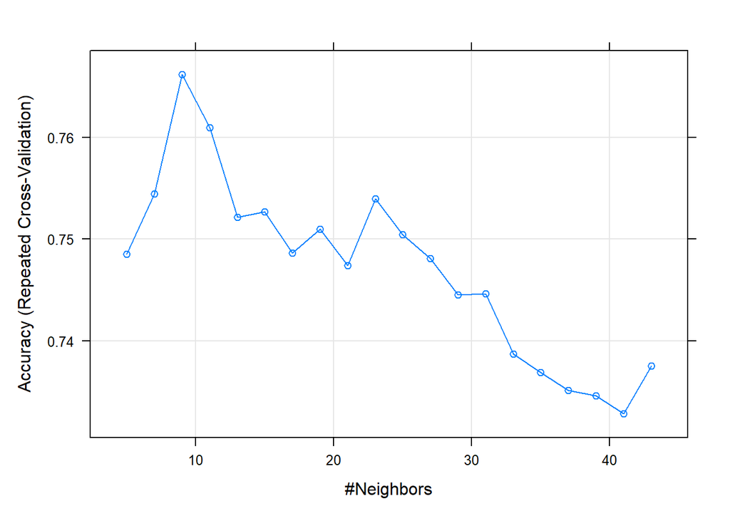

```r
plot(model_knn)
```

### 5.3.2 Predict happiness level by K-Nearest Neighbours model

```r
pred_knn <- predict(model_knn, data_test)

cm_knn<-confusionMatrix(pred_knn, data_test$Happy.Level)

cm_knn
```

```
## Confusion Matrix and Statistics
##
##           Reference
## Prediction High Mid Low
##       High   33   7   0
##       Mid     5  56   8
##       Low     0   6  24
##
## Overall Statistics
##
##                Accuracy : 0.8129
##                  95% CI : (0.7381, 0.874)
##     No Information Rate : 0.4964
##     P-Value [Acc > NIR] : 0.0000000000000105
##
##                   Kappa : 0.7008
##
##  Mcnemar's Test P-Value : NA
##
## Statistics by Class:
##
##                      Class: High Class: Mid Class: Low
## Sensitivity               0.8684     0.8116     0.7500
## Specificity               0.9307     0.8143     0.9439
## Pos Pred Value            0.8250     0.8116     0.8000
## Neg Pred Value            0.9495     0.8143     0.9266
## Prevalence                0.2734     0.4964     0.2302
## Detection Rate            0.2374     0.4029     0.1727
## Detection Prevalence      0.2878     0.4964     0.2158
## Balanced Accuracy         0.8996     0.8129     0.8470
```

### 5.3.3 Feature Importance

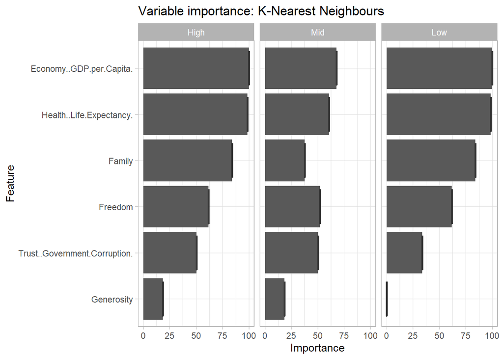

```r
# Create object of importance of our variables
knn_importance <- varImp(model_knn)

# Create box plot of importance of variables
ggplot(data = knn_importance, mapping = aes(x = knn_importance[,1])) + # Data & mapping
  geom_boxplot() + # Create box plot
  labs(title = "Variable importance: K-Nearest Neighbours ") + # Title
  theme_light() # Theme
```

## 5.4 Naive Bayes Classification model for predicting Happy Level

### 5.4.1 Train Naive Bayes Classification model model with data_train

```r
model_nb <- train(Happy.Level~.,
                  data_train,
                  method="naive_bayes",
                  preProcess = c("center","scale"),
                  metric='Accuracy',
                  trControl=tc)

model_nb
```

```
## Naive Bayes
##
## 566 samples
##   6 predictor
##   3 classes: 'High', 'Mid', 'Low'
##
## Pre-processing: centered (6), scaled (6)
## Resampling: Cross-Validated (10 fold, repeated 3 times)
## Summary of sample sizes: 510, 510, 508, 509, 510, 509, ...
## Resampling results across tuning parameters:
##
##   usekernel  logLoss    AUC        prAUC      Accuracy   Kappa      Mean_F1
##   FALSE      0.7237029  0.8965975  0.7632952  0.7597568  0.6156457  0.7583292
##    TRUE      0.7014796  0.8940879  0.7646527  0.7662536  0.6232512  0.7631400
##   Mean_Sensitivity  Mean_Specificity  Mean_Pos_Pred_Value  Mean_Neg_Pred_Value
##   0.7572299         0.8664677         0.7686608            0.8689490
##   0.7596220         0.8684121         0.7801272            0.8726667
##   Mean_Precision  Mean_Recall  Mean_Detection_Rate  Mean_Balanced_Accuracy
##   0.7686608       0.7572299    0.2532523            0.8118488
##   0.7801272       0.7596220    0.2554179            0.8140171
##
## Tuning parameter 'laplace' was held constant at a value of 0
## Tuning
##  parameter 'adjust' was held constant at a value of 1
## Accuracy was used to select the optimal model using the largest value.
## The final values used for the model were laplace = 0, usekernel = TRUE
##  and adjust = 1.
```

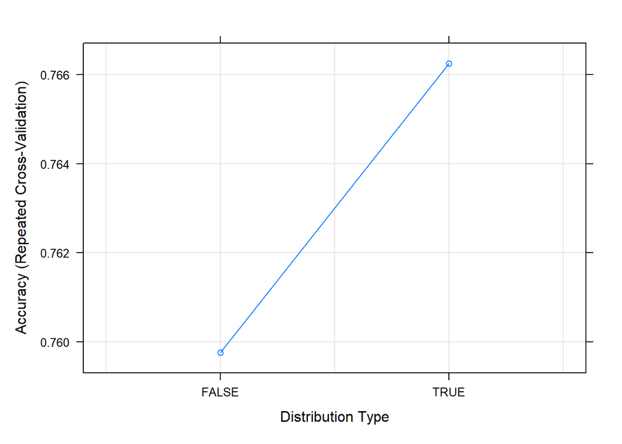

```r
plot(model_nb)
```

### 5.4.2 Predict happiness Level by Naive Bayes

```r
pred_nb <- predict(model_nb, data_test)

cm_nb<-confusionMatrix(pred_nb, data_test$Happy.Level)

cm_nb
```

```
## Confusion Matrix and Statistics
##
##           Reference
## Prediction High Mid Low
##       High   31   4   0
##       Mid     7  54   8
##       Low     0  11  24
##
## Overall Statistics
##
##                Accuracy : 0.7842
##                  95% CI : (0.7065, 0.8494)
##     No Information Rate : 0.4964
##     P-Value [Acc > NIR] : 0.000000000002766
##
##                   Kappa : 0.6557
##
##  Mcnemar's Test P-Value : NA
##
## Statistics by Class:
##
##                      Class: High Class: Mid Class: Low
## Sensitivity               0.8158     0.7826     0.7500
## Specificity               0.9604     0.7857     0.8972
## Pos Pred Value            0.8857     0.7826     0.6857
## Neg Pred Value            0.9327     0.7857     0.9231
## Prevalence                0.2734     0.4964     0.2302
## Detection Rate            0.2230     0.3885     0.1727
## Detection Prevalence      0.2518     0.4964     0.2518
## Balanced Accuracy         0.8881     0.7842     0.8236
```

### 5.4.3 Feature Importance

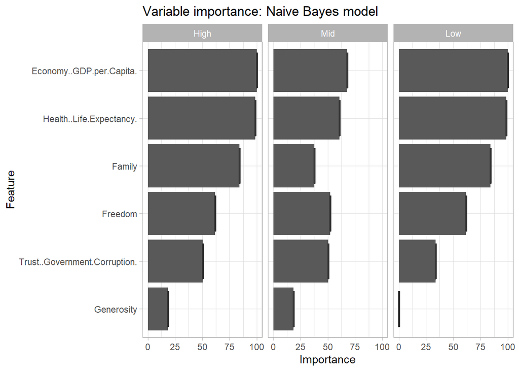

```r
# Create object of importance of our variables
nb_importance <- varImp(model_nb)

# Create box plot of importance of variables
ggplot(data = nb_importance, mapping = aes(x = nb_importance[,1])) + # Data & mapping
  geom_boxplot() + # Create box plot
  labs(title = "Variable importance: Naive Bayes model") + # Title
  theme_light() # Theme
```

## 5.5 Model Evaluation by AUC

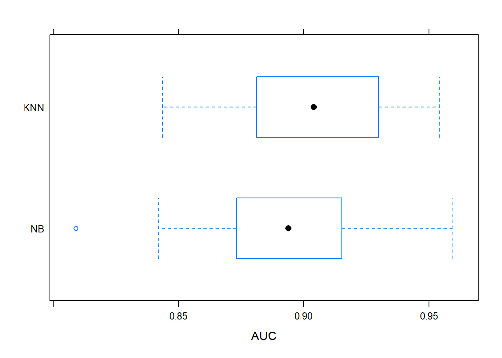

```r
model_list <- list(KNN = model_knn, NB=model_nb)
resamples <- resamples(model_list)

bwplot(resamples, metric="AUC")
```

## 5.6 Model Evaluation by Prediction Accurancy

```r
data.frame(
  K_Nearest_Neighbours= cm_knn$overall[1],
  Naive_Bayes=  cm_nb$overall[1]
)
```

```
##          K_Nearest_Neighbours Naive_Bayes
## Accuracy            0.8129496   0.7841727
```

# 6 Discussion

## 6.1 Happiness Countries from 2015 to 2019

Although the top 10 happiest country’s ranking position changes from year to year, the countries did not change from 2015 to 2019. They are still on the top 10 happiest country list. The countries are Finland, Denmark, Norway, Iceland, Netherlands, Switzerland, Sweden, New Zealand, Canada and Australia.

## 6.2 Progressive Countries from 2015 to 2019

The top 10 progressive countries are Benin, Togo, Ivory Coast, Burundi, Burkina Faso, Guinea, Gabon, Cambodia, Honduras and Congo (Brazzaville). The happiness value of people in these countries did not declined, and the people are getting happier every year.

## 6.3 The Main Factor Affects Happiness

The factor that most affect happiness is Economic GDP per capita, It is probably because income can let people meet their basic needs, so it is quite important and will affect people’s happiness, and another main factor is health.

## 6.4 Happiness Score Prediction (Regression Model)

Random Forest Regression comes out with the best result compared to others, Support Vector Regression model and Multiple Linear Regression are good in prediction. And finally, Decision Tree was the worst algorithm to predict happiness scores.

## 6.5 Happiness Level Prediction (Classification Model)

K-Nearest Neighbor Classification model is better than Naive Bayes Classification model in our project result since the prediction accuracy of K-Nearest Neighbor Classification model is higher than the other one.

# 7 Conclusion

In conclusion, this study has shown that happiness depends on a huge range of inﬂuences. Thus, regular collection of happiness data on a large scale can inform policy-making and help us identify what “deliverables” should be created to foster well-being. In other words, moving to a happier country could plausibly make you happier. By the same token, moving to a less happy country could reduce your level of happiness. Emotions are contagious, even at a national level.

# 8 Reference

Decision Tree for Regression in R Programming - GeeksforGeeks. (2020, July 26). GeeksforGeeks. https://www.geeksforgeeks.org/decision-tree-for-regression-in-r-programming/

https://www.facebook.com/verywell. (2020). How Do Psychologists Define Happiness? Verywell Mind. https://www.verywellmind.com/what-is-happiness-4869755

K-NN Classifier in R Programming - GeeksforGeeks. (2020, June 18). GeeksforGeeks. https://www.geeksforgeeks.org/k-nn-classifier-in-r-programming/#:~:text=K%2DNearest%20Neighbor%20or%20K,underlying%20data%20or%20its%20distribution.

Nikola O. (2021, December 29). Random Forest Regression in R: Code and Interpretation. Hackernoon.com. https://hackernoon.com/random-forest-regression-in-r-code-and-interpretation

Ortiz-Ospina, E., & Roser, M. (2013, May 14). Happiness and Life Satisfaction. Our World in Data. https://ourworldindata.org/happiness-and-life-satisfaction

Random Forest Approach in R Programming - GeeksforGeeks. (2020, May 31). GeeksforGeeks. https://www.geeksforgeeks.org/random-forest-approach-in-r-programming/#:~:text=Random%20Forest%20in%20R%20Programming,when%20employed%20on%20its%20own.

R - Multiple Regression. (2022). Tutorialspoint.com. https://www.tutorialspoint.com/r/r_multiple_regression.htm

Scatter Plots - R Base Graphs - Easy Guides - Wiki - STHDA. (2020). Sthda.com. http://www.sthda.com/english/wiki/scatter-plots-r-base-graphs#:~:text=A%20scatter%20plot%20can%20be,using%20the%20function%20loess().

Support Vector Regression Example with SVM in R. (2019, September 5). Datatechnotes.com. https://www.datatechnotes.com/2019/09/support-vector-regression-example-with.html#:~:text=Support%20Vector%20Machine%20is%20a,for%20regression%20problem%20in%20R.

Sustainable Development Solutions Network. (2012). World Happiness Report. Kaggle.com. https://www.kaggle.com/datasets/unsdsn/world-happiness